# Term-Structure Extraction

## Bootstrapping and Valuation of Swap

Extract an interest-rate term structure from market data and use it to value swaps with transparency and rigour.

Fixed Income Term Structure Bootstrapping Python

### Overview

- Goal: derive a term structure (zero curve / discount factors) and price swaps consistently.
- Approach: bootstrap from market instruments → interpolate yields/discounts → compute present values of cash flows.

### Quick reference

# Import packages

```python
import pandas as pd
import numpy as np
import matplotlib.pyplot as plt
from scipy.optimize import fsolve
from scipy.interpolate import interp1d
```

# Import data

```python
df = pd.DataFrame(
    [
        {"Type": "BBSW", "Term": "1 month", "Rate": 3.6909},
        {"Type": "BBSW", "Term": "2 months", "Rate": 3.6963},
        {"Type": "BBSW", "Term": "3 months", "Rate": 3.7018},
        {"Type": "BBSW", "Term": "4 months", "Rate": 3.7225},
        {"Type": "BBSW", "Term": "5 months", "Rate": 3.7375},
        {"Type": "BBSW", "Term": "6 months", "Rate": 3.7772},
        {"Type": "Swap", "Term": "1 year", "Rate": 3.61},
        {"Type": "Swap", "Term": "2 years", "Rate": 3.52},
        {"Type": "Swap", "Term": "3 years", "Rate": 3.55},
        {"Type": "Swap", "Term": "4 years", "Rate": 3.62},
        {"Type": "Swap", "Term": "5 years", "Rate": 3.72},
        {"Type": "Swap", "Term": "6 years", "Rate": 3.78},
        {"Type": "Swap", "Term": "7 years", "Rate": 3.93},
        {"Type": "Swap", "Term": "10 years", "Rate": 4.18},
        {"Type": "Swap", "Term": "12 years", "Rate": 4.30},
        {"Type": "Swap", "Term": "15 years", "Rate": 4.42},
        {"Type": "Swap", "Term": "20 years", "Rate": 4.51},
        {"Type": "Swap", "Term": "25 years", "Rate": 4.51},
        {"Type": "Swap", "Term": "30 years", "Rate": 4.48},
        {"Type": "Swap", "Term": "40 years", "Rate": 4.28},
    ]
)

df
```

|  | Type | Term | Rate |
| --- | --- | --- | --- |
| 0 | BBSW | 1 month | 3.6909 |
| 1 | BBSW | 2 months | 3.6963 |
| 2 | BBSW | 3 months | 3.7018 |
| 3 | BBSW | 4 months | 3.7225 |
| 4 | BBSW | 5 months | 3.7375 |
| 5 | BBSW | 6 months | 3.7772 |
| 6 | Swap | 1 year | 3.6100 |
| 7 | Swap | 2 years | 3.5200 |
| 8 | Swap | 3 years | 3.5500 |
| 9 | Swap | 4 years | 3.6200 |
| 10 | Swap | 5 years | 3.7200 |
| 11 | Swap | 6 years | 3.7800 |
| 12 | Swap | 7 years | 3.9300 |
| 13 | Swap | 10 years | 4.1800 |
| 14 | Swap | 12 years | 4.3000 |
| 15 | Swap | 15 years | 4.4200 |
| 16 | Swap | 20 years | 4.5100 |
| 17 | Swap | 25 years | 4.5100 |
| 18 | Swap | 30 years | 4.4800 |
| 19 | Swap | 40 years | 4.2800 |

The above is the Australian interest rate data on 30 July 2025. Note that the bank bill swap rate (BBSW) is quoted per annum with simple compounding, and "Swaps are quoted on a quarterly basis for maturities out to 3 years and on a semi-annual basis for maturities 4 years and greater." AFMA (2023), Interest Rate Derivative Conventions (see https://afma.com.au/getattachment/Standards/Market-Conventions/Sections/Content/Interest-Rate-Derivative-Conventions-2023-07.pdf?lang=en-AU )

# Term structure construction

**Workflow**

- 🔍 Bootstrap short-end (BBSW) using money-market conventions.
- ⚖️ Solve swap PV equations to infer mid/long-term discount factors.
- 🧮 Log-linear Interpolate to fill the curve between pillars.
- 📐 Convert: discount factor term structure $B(0,t)$ ↔ spot instantaneous forward rate $f(0,t)$

**Outputs**

- discount factors $B(0,t)$, and interpolated term-structure.

**Assumption**

- Day count convention is 30/360

**Rate formulas** $$ \begin{align*} \text{BBSW}(T) &= \frac{1}{T} \left( \frac{1}{B(0,T)} - 1 \right) \\ \text{Swap rate}(0,\mathbb{T}) &= \frac{1 - B(0,T_n)}{\sum_{i=1}^{N} (T_i - T_{i-1}) B(0,T_i)} \\ \end{align*} $$ **Log-linear interpolation of discount factors** $$ \log B(0,t) = \log B(0,t_i) + \frac{t - t_i}{t_{i+1} - t_i} \left(\log B(0,t_{i+1}) - \log B(0,t_i)\right), \quad t \in [t_i, t_{i+1}] $$

```python
def term_structure_constructor(df):
    new_df = pd.DataFrame(df)
    ts = np.array(df["Term"].str.split(" ", expand=True)[0].astype(float).values)
    ts[:6] = ts[:6] / 12
    new_df["Term"] = ts
    new_df["Rate"] = new_df["Rate"] / 100

    def target_func(x):
        B = np.array([1] + list(x))
        B = np.log(B)
        T = np.array([0] + list(new_df["Term"]))
        interp = interp1d(T, B, kind="linear", fill_value="interpolate")

        def log_lin(t):
            return np.exp(interp(t))

        equations = []
        for i in range(len(new_df)):
            if new_df.iloc[i, 0] == "BBSW":
                equations.append(
                    (1 / log_lin(new_df.iloc[i, 1]) - 1) / new_df.iloc[i, 1]
                    - new_df.iloc[i, 2]
                )
            else:
                T_i = new_df.iloc[i, 1]
                rate = new_df.iloc[i, 2]
                freq = 1 / 4 if T_i <= 3 else 1 / 2
                payments = np.arange(freq, T_i + freq, freq)
                sum_dfs = np.sum([log_lin(t) for t in payments])
                equations.append((1 - log_lin(T_i)) / (freq * sum_dfs) - rate)
        return equations

    B = fsolve(target_func, [0.5] * len(new_df))
    B = np.array([1] + list(B))
    B = np.log(B)
    T = np.array([0] + list(new_df["Term"]))
    interp = interp1d(T, B, kind="linear", fill_value="interpolate")

    def log_lin(t):
        return np.exp(interp(t))

    # prepend a zero-term row (time 0, DF = 1 implicitly via interpolation)
    new_row = pd.DataFrame([{"Type": "Cash", "Term": 0.0, "Rate": 0.0}])
    new_df = pd.concat([new_row, new_df], ignore_index=True)
    new_df["Discount Factor"] = [log_lin(t) for t in new_df["Term"]]

    def ifr_calculator(t):
        idx_start = new_df[new_df["Term"] <= t].index[-1]
        if idx_start == len(new_df) - 1:
            idx_start -= 1
        T1 = new_df.loc[idx_start, "Term"]
        T2 = new_df.loc[idx_start + 1, "Term"]
        B1 = np.log(new_df.loc[idx_start, "Discount Factor"])
        B2 = np.log(new_df.loc[idx_start + 1, "Discount Factor"])
        slope = (B2 - B1) / (T2 - T1)
        return -slope

    return log_lin, new_df, ifr_calculator
```

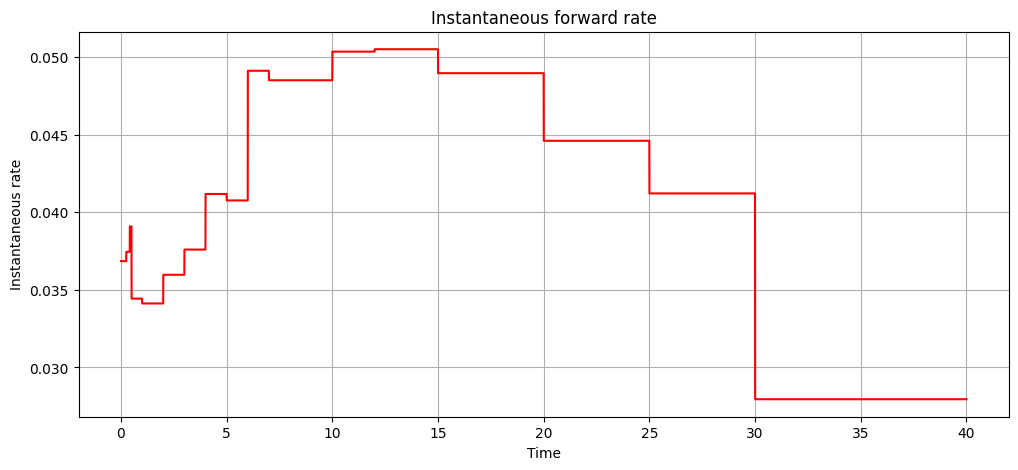

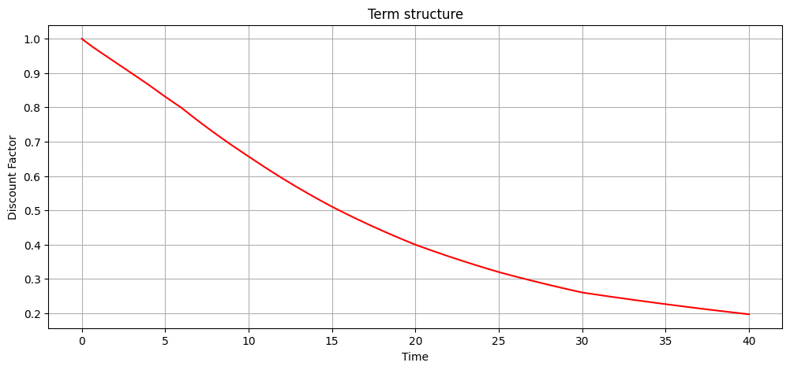

```
Term structure is define by the given zero counpon bonds price below:
```

|  | Type | Term | Rate | Discount Factor |
| --- | --- | --- | --- | --- |
| 0 | Cash | 0.000000 | 0.000000 | 1.000000 |
| 1 | BBSW | 0.083333 | 0.036909 | 0.996934 |
| 2 | BBSW | 0.166667 | 0.036963 | 0.993877 |
| 3 | BBSW | 0.250000 | 0.037018 | 0.990830 |
| 4 | BBSW | 0.333333 | 0.037225 | 0.987744 |
| 5 | BBSW | 0.416667 | 0.037375 | 0.984666 |
| 6 | BBSW | 0.500000 | 0.037772 | 0.981464 |
| 7 | Swap | 1.000000 | 0.036100 | 0.964712 |
| 8 | Swap | 2.000000 | 0.035200 | 0.932349 |
| 9 | Swap | 3.000000 | 0.035500 | 0.899408 |
| 10 | Swap | 4.000000 | 0.036200 | 0.866224 |
| 11 | Swap | 5.000000 | 0.037200 | 0.831283 |
| 12 | Swap | 6.000000 | 0.037800 | 0.798084 |
| 13 | Swap | 7.000000 | 0.039300 | 0.759838 |
| 14 | Swap | 10.000000 | 0.041800 | 0.656955 |
| 15 | Swap | 12.000000 | 0.043000 | 0.594034 |
| 16 | Swap | 15.000000 | 0.044200 | 0.510530 |
| 17 | Swap | 20.000000 | 0.045100 | 0.399690 |
| 18 | Swap | 25.000000 | 0.045100 | 0.319800 |
| 19 | Swap | 30.000000 | 0.044800 | 0.260252 |
| 20 | Swap | 40.000000 | 0.042800 | 0.196781 |

```
Any discount factor at the time in range [0,40] will be calculated via log-linear interpolation of the 2 closest zero counpon bonds on both side of the time in the above table
```

```python
df_calculator, term_structure, ifr_calculator = term_structure_constructor(df)
t = np.arange(0, 40, 1 / 1000)
dfs = list(map(lambda x: df_calculator(x), t))
irf = list(map(lambda x: ifr_calculator(x), t))
plt.figure(figsize=(12, 5))
plt.plot(t, irf, linestyle="-", color="r", label="Instantaneous Rate")
plt.title("Instantaneous forward rate")
plt.xlabel("Time")
plt.ylabel("Instantaneous rate")
plt.grid(True)
plt.show()

plt.figure(figsize=(12, 5))
plt.plot(t, dfs, linestyle="-", color="r")
plt.title("Term structure")
plt.xlabel("Time")
plt.ylabel("Discount Factor")
plt.grid(True)
plt.show()
print("Term structure is define by the given zero counpon bonds price below:")
display(term_structure)
print(
    "Any discount factor at the time in range [0,40] will be calculated via log-linear interpolation of the 2 closest zero counpon bonds on both side of the time in the above table"
)
```

**Term structure of three-month simple compounded forward rates**

Term structure of three-month simple compounded forward rates implied by the term structure of discount factors can be plotted as follows: $$ \begin{align*} \text{r}(t,T,T+\delta) &= \frac{1}{\delta} \left( \frac{B(t,T)}{B(t,T+\delta)} - 1 \right) \\ \end{align*} $$

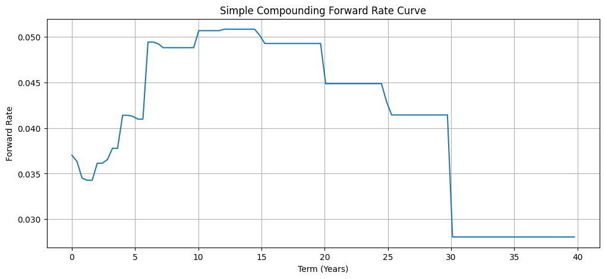

```python
def simple_compounding_forward_rate_calculator(t):
    if t < 0 or t > term_structure.iloc[-1, 1] - 1 / 4:
        return ValueError(f"t must be in range [0,{term_structure.iloc[-1, 1]-1/4}]")
    B_T1 = df_calculator(t)
    B_T2 = df_calculator(t + 1 / 4)
    return (B_T1 / B_T2 - 1) * 4


ts = np.linspace(0, term_structure.iloc[-1, 1] - 1 / 4, 100)
forward_rates = [simple_compounding_forward_rate_calculator(t) for t in ts]
plt.figure(figsize=(12, 5))
plt.plot(ts, forward_rates)
plt.title("Simple Compounding Forward Rate Curve")
plt.xlabel("Term (Years)")
plt.ylabel("Forward Rate")
plt.grid()
plt.show()
```

# Swap valuation

## Swap rate calculation

Consider an eleven-year interest rate swap paying fixed and receiving floating semi-annually. Determine the fixed rate of this swap such that the value of the swap is zero.

$$ \begin{align*} \text{Swap rate}(0,\mathbb{T}) &= \frac{1 - B(0,T_n)}{\sum_{i=1}^{22} (T_i - T_{i-1}) B(0,T_i)} \\ T_i &= \frac{i}{2}, \quad i = 1, 2, \ldots, 22 \\ \end{align*} $$

```python
ts = np.arange(0.5, 11.5, 0.5)
dfs = [df_calculator(t) for t in ts]
rate = (1 - dfs[-1]) / (0.5 * np.sum(dfs))
print(f"Fixed rate is {rate:.4f} or {rate*100:.2f}%")
```

```
Fixed rate is 0.0425 or 4.25%
```

## Swap valuation

Suppose that one month ago you entered into a two-year interest rate swap paying a fixed rate of 3.7% and receiving floating (based on three-month BBSW) quarterly. Three-month BBSW on 30 June 2025 was 3.6037%.

```python
rate = 0.037
prev_BBSW = 0.036037
T = 2
freq = 1 / 4
ts = np.arange(freq, T + freq, freq) - 1 / 12
dfs = [df_calculator(t) for t in ts]
pv_fixed_payment = rate * freq * np.sum(dfs)
pv_from_2nd_float_payment = dfs[0] - dfs[-1]
pv_1st_float_payment = prev_BBSW * freq * dfs[0]
value = pv_from_2nd_float_payment + pv_1st_float_payment - pv_fixed_payment
print(f"Value of the swap is {value:.4f}")
```

```
Value of the swap is -0.0035
```